# EX11

# Q2

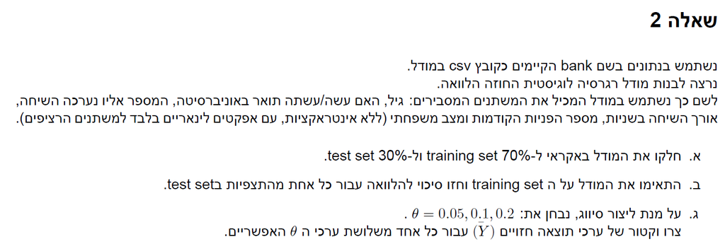

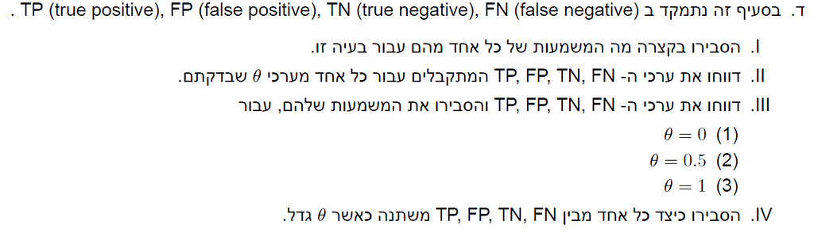

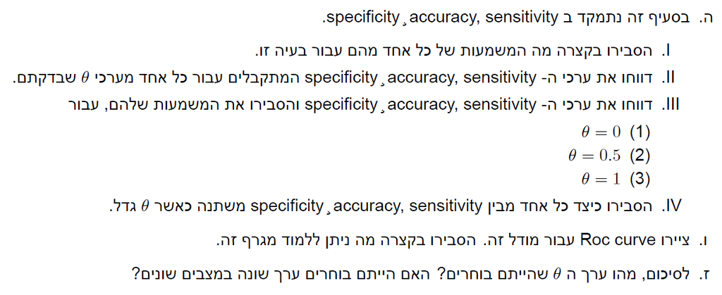

## a

```r
train_inds <- sample(1:nrow(X),floor(0.7*nrow(X)))
train <- bank %>% slice(train_inds)
test <- bank %>% slice(-train_inds)
```

## b

```r
logistic_model <- glm(y~.,data = train,family = "binomial")
test$y_pred <- predict(logistic_model,test,type = "response")
test
```

```
## # A tibble: 12,357 x 9
##      age university housing duration contact   marital previous     y y_pred
##    <dbl> <chr>      <chr>      <dbl> <chr>     <chr>      <dbl> <dbl>  <dbl>
##  1    56 no         no           261 telephone married        0     0 0.0365
##  2    40 no         no           151 telephone married        0     0 0.0174
##  3    45 no         no           198 telephone married        0     0 0.0230
##  4    24 no         yes          380 telephone single         0     0 0.0481
##  5    25 no         yes          222 telephone single         0     0 0.0272
##  6    29 no         no           137 telephone single         0     0 0.0212
##  7    35 no         yes          146 telephone married        0     0 0.0155
##  8    50 no         yes          353 telephone married        0     0 0.0459
##  9    55 no         yes          262 telephone married        0     0 0.0361
## 10    35 yes        no            99 telephone married        0     0 0.0175
## # ... with 12,347 more rows
```

## c

```r
test_with_thetas <- test %>% mutate(theta05 = as.numeric(y_pred>0.05)) %>%
  mutate(theta1 = as.numeric(y_pred>0.1)) %>%
  mutate(theta2 = as.numeric(y_pred>0.2))
test_with_thetas %>% summarise(across(c(theta05,theta1,theta2),mean))
```

```
## # A tibble: 1 x 3
##   theta05 theta1 theta2
##     <dbl>  <dbl>  <dbl>
## 1   0.551  0.288  0.139
```

## d

#### I

*false negative we identified an observation as negative (meaning no loan), but the true value was positive*

*true negative we identified an observation as negative (meaning no loan) and we were correct*

#### II

```r
tbl_theta <- function(theta){
  cm <- confusionMatrix(data = factor(as.numeric(test$y_pred>theta),levels = c(0,1)),reference  = factor(test$y))$table
  glue("for theta = {theta}
       fn = {cm[2,1]}
       tn = {cm[1,1]}
       fp = {cm[1,2]}
       tp = {cm[2,2]}
       ")
}
tbl_theta(0.05)
```

```
## for theta = 0.05
## fn = 5417
## tn = 5492
## fp = 62
## tp = 1386
```

```r
tbl_theta(0.1)
```

```
## for theta = 0.1
## fn = 2378
## tn = 8531
## fp = 272
## tp = 1176
```

```r
tbl_theta(0.2)
```

```
## for theta = 0.2
## fn = 891
## tn = 10018
## fp = 624
## tp = 824
```

#### III

```r
tbl_theta(0)
```

```
## for theta = 0
## fn = 10909
## tn = 0
## fp = 0
## tp = 1448
```

```r
tbl_theta(0.5)
```

```
## for theta = 0.5
## fn = 177
## tn = 10732
## fp = 1095
## tp = 353
```

```r
tbl_theta(1)
```

```
## for theta = 1
## fn = 0
## tn = 10909
## fp = 1448
## tp = 0
```

*for theta = 0.5 we assume that the chance of taking a lone is the same as not taking one*

#### IV

*as theta increases: fn decrease*

*tn increase*

*tp decrease*

## e

#### I

*specificity is P(Y_pred = 0|Y=0)*

*accuracy is the ratio of our correctly classified predictions out of all the observations*

*sensitivity is P(Y_pred = 1|Y=1)*

#### II + III

```r
acc_vales <- function(theta){
  cm <- confusionMatrix(data = factor(as.numeric(test$y_pred>theta),levels = c(0,1)),reference  = factor(test$y))
  acc = cm$overall["Accuracy"]
  sensi = cm$byClass["Sensitivity"]
  speci = cm$byClass["Specificity"]
  glue("for theta = {theta}
       Accuracy = {acc}
       Sensitivity = {sensi}
       Specificity = {speci}
       ")
}

map(c(0,0.05,0.1,0.2,0.5,1),acc_vales)
```

```
## [[1]]
## for theta = 0
## Accuracy = 0.117180545439832
## Sensitivity = 0
## Specificity = 1
##
## [[2]]
## for theta = 0.05
## Accuracy = 0.5566075908392
## Sensitivity = 0.503437528646072
## Specificity = 0.957182320441989
##
## [[3]]
## for theta = 0.1
## Accuracy = 0.78554665371854
## Sensitivity = 0.782014850123751
## Specificity = 0.812154696132597
##
## [[4]]
## for theta = 0.2
## Accuracy = 0.877397426559845
## Sensitivity = 0.918324319369328
## Specificity = 0.569060773480663
##
## [[5]]
## for theta = 0.5
## Accuracy = 0.897062393784899
## Sensitivity = 0.98377486479054
## Specificity = 0.24378453038674
##
## [[6]]
## for theta = 1
## Accuracy = 0.882819454560168
## Sensitivity = 1
## Specificity = 0
```

#### IV

*Accuracy increases then decreases*

*Sensitivity increases*

*Specificity decreases*

## f

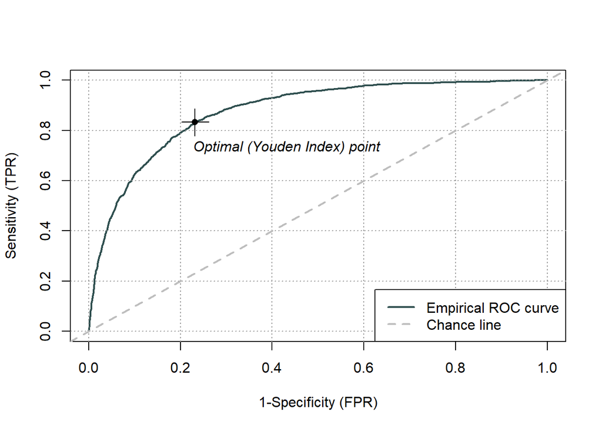

```r
## Warning: package 'ROCit' was built under R version 3.5.2
ROCit_obj <- rocit(score=test$y_pred,class=factor(test$y))
plot(ROCit_obj)
```

## g

*it depends what we are more concerned with is it better to predict a loan but a person wont take it or not to predict but he would take it?*

# Q3

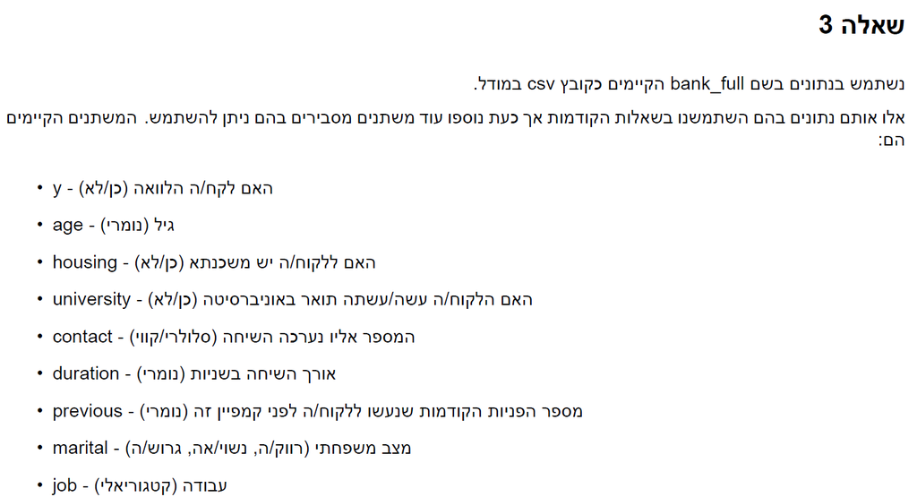

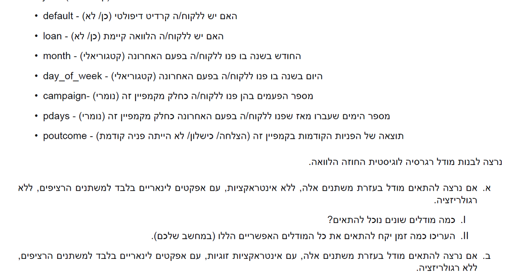

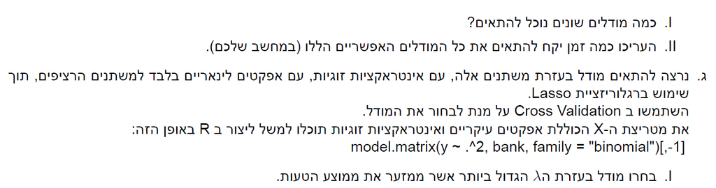

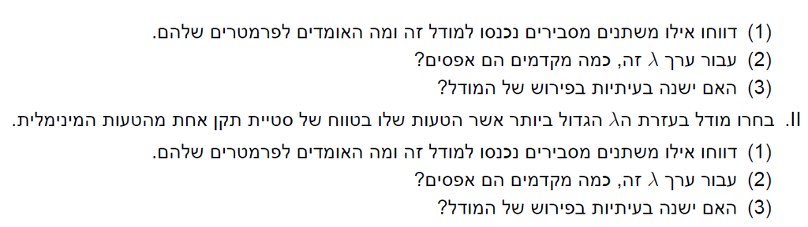

## a

#### I

$$2^{14}= 16384 \ models$$

#### II

*lets assume that training time is symetric around 7 (the mean number of predictors)*

```r
bank_full <- read_csv("bank_full.csv") %>% mutate(y = ifelse(y == "yes",1,0)) %>% select(-1,-2)
totsec <- mean(microbenchmark(glm(y~.,data = bank_full[c(sample(colnames(bank_full)[-14],7),"y")],family = "binomial"), times = 100, unit = "s")$time/10^9)
glue("the estimated amout of time is: {totsec*16384/60} mintues ")
```

```
## the estimated amout of time is: 142.092992785067 mintues
```

## b

#### I

$$2^{\binom{14}{2} +14} \approx 4.05*10^{31} models$$

#### II

*ill make the same assumption but now i will use all the interactions for the selected predictors*

```r
totmin <- mean(microbenchmark(glm(y~.^2,data = bank_full[c(sample(colnames(bank_full)[-14],7),"y")],family = "binomial"), times = 10, unit = "s")$time/10^9)
glue("the estimated amout of time is: {totmin*4.05*10^31/60/60/24/365} years")
```

```
## the estimated amout of time is: 4.56992562071918e+24 years
```

## c

#### I

*cv.glmnet does not work for some reason, i left the code*

```r
X <- model.matrix(y~ .^2,data = bank_full)
y <- bank_full$y

las_cv <- cv.glmnet(X,y,family = "binomial",alpha = 1,nfolds = 5,lambda = seq(0.005,0.15,length.out=50))
las_cv

plot(las_cv)
lasso_model <- glmnet(X,y,family = "binomial",alpha = 1,lambda = las_cv$lambda.min)
```

##### 1

```r
coef(lasso_model)
```

[output not shown]

##### 2

```r
ncol(X) - tidy(cv_lambda) %>% filter(near(lambda,las_cv$lambda.min)) %>% pull (nzero)
```

[output not shown]

#### II

##### 1

```r
plot(las_cv)

ci <- min(cv_lambda$cvm) + c(-1,1)* cv_lambda$cvsd[which.min(cv_lambda$cvm)]
# all values are begger then the lower bound
lambdas <- cv_lambda$lambda[cv_lambda$cvm < ci[2]]
biggest_lambda <- max(lambdas)
biggest_lambda
```

[output not shown]

##### 2

```r
ncols(X) - tidy(cv_lambda) %>% filter(near(lambda,las_cv$lambda.min)) %>% pull (nzero)
```

[output not shown]

##### 3

*too many predictors makes the interpettebbilty of the model harder*